# Data Project Team GoBills

STAT 420, Summer 2023, Naveen Baskaran (nc42), Frank Salamone (frankns2), Aleksandr Stpenko(as99)

### 1. The names of the students who will be contributing to the group project.

Naveen Baskaran (nc42) Frank Salamone (frankns2) Aleksandr Stepenko (as99)

### 2. A tentative title for the project.

“Predicting Airbnb Prices in London on Weekends”

### 3. Description of the data file (what they contain including number of variables and number of records). You do not necessarily have to list all the variables, but at least mention those of greatest importance.

The most important variable is realSum, which is the total price of the listing, and will serve as our response. There are many categorical variables, including, most importantly, room_type, room_shared, and host_is_superhost. The distance to city center, dist, and metro_dist, the distance to the nearest metro station, will be important continuous numeric variables.

### 4. Background information on the data sets, including specific citation of their source (so that I can also access it).

This dataset was found on Kaggle. Briefly, it is a part of a larger set of Airbnb prices in European cities. Please see the dataset description below (taken from Kaggle).

https://www.kaggle.com/datasets/thedevastator/airbnb-prices-in-european-cities?resource=download

“This dataset provides a comprehensive look at Airbnb prices in some of the most popular European cities. Each listing is evaluated for various attributes such as room types, cleanliness and satisfaction ratings, bedrooms, distance from the city center, and more to capture an in-depth understanding of Airbnb prices on both weekdays and weekends. Using spatial econometric methods, we analyze and identify the determinants of Airbnb prices across these cities. Our dataset includes information such as realSum (the total price of the listing), room_type (private/shared/entire home/apt), host_is_superhost (boolean value indicating if host is a superhost or not), multi (indicator whether listing is for multiple rooms or not), biz (business indicator) , guest_satisfaction_overall (overall rating from guests comparing all listings offered by host ), bedrooms, dist (distance from city center) , lng & lat coordinates for location identification etc. We hope that this data set offers insight into how global markets are affected by social dynamics and geographical factors which in turn determine pricing strategies for optimal profitability!”

### 5. A brief statement of the business, science, research, or personal interest you have in the data set which you hope to explore.

From an outsider’s perspective, the Airbnb platform has revolutionized the renting of rooms much as Uber has revolutionized ridesharing. Airbnb allows users of the platform to monetize property that they would not be able to otherwise. In order to determine if renting out a room is a good business case or worth the owner’s time, it would be helpful to have an estimate of how much income the room would generate. Our proposal is to develop a model, trained on the London Weekend Airbnb data, that could predict the room rental income based on predictors known to the person putting the room up for rent.

### 6. Evidence that the data can be loaded into R. Load the data, and print the first few values of the response variable as evidence.

**Solution**

```r
london = read.csv("london_weekends.csv")
head(london$realSum)
```

```
## [1] 121.1223 195.9124 193.3253 180.3899 405.7010 354.1946
```

```r
head(london)
```

```
##   X  realSum       room_type room_shared room_private person_capacity
## 1 0 121.1223    Private room       False         True               2
## 2 1 195.9124    Private room       False         True               2
## 3 2 193.3253    Private room       False         True               3
## 4 3 180.3899    Private room       False         True               2
## 5 4 405.7010 Entire home/apt       False        False               3
## 6 5 354.1946 Entire home/apt       False        False               2
##   host_is_superhost multi biz cleanliness_rating guest_satisfaction_overall
## 1             False     0   0                  6                         69
## 2             False     1   0                 10                         96
## 3             False     1   0                 10                         95
## 4             False     1   0                  9                         87
## 5             False     0   1                  7                         65
## 6             False     0   1                  9                         93
##   bedrooms     dist metro_dist attr_index attr_index_norm rest_index
## 1        1 5.734117  0.4370940   222.8822        15.49341   470.0885
## 2        1 4.788905  1.4640505   235.3858        16.36259   530.1335
## 3        1 4.596677  0.4503062   268.9138        18.69325   548.9876
## 4        1 2.054769  0.1326705   472.3813        32.83707  1021.2711
## 5        0 4.491277  0.3541075   318.4915        22.13958   692.7754
## 6        0 4.467894  0.3507494   321.8646        22.37406   703.0686
##   rest_index_norm      lng      lat
## 1        8.413765 -0.04975 51.52570
## 2        9.488466 -0.08475 51.54210
## 3        9.825922 -0.14585 51.54802
## 4       18.278973 -0.10611 51.52108
## 5       12.399473 -0.18797 51.49399
## 6       12.583702 -0.18805 51.49473
```

```r
nrow(london)
```

```
## [1] 5379
```

```r
ncol(london)
```

```
## [1] 20
```

Methods First part: Exploratory analysis. Lay out what variables look like they are related to the response through correlation analysis. Scatterplot matrix. Basic analysis. Hint on possibility of collinearity. Second part: Some connector between predictors and response in linear fashon. Main effects analysis. Aren’t completely happy. Give RMSE, RSE, adjusted r^2. Next try to remove predictors to increase explanatory power. Third part: Try transformations, interactions. Polynomial terms. Do backward elimination from your big model from above. Go in same order as introduced in the course. Model assumptions Train and test split

Results Dont’ characterize all models. 2 or 3 or 4models that seem to be the best. Say why fully additive model didn’t work. Show progress that you made. End results. Hit the highlights. Discussion Table with candidate model, with RMSC, residuals, assumptions. Argue why model is the best.

## Introduction

rubric: Introduction Lay everything out in terms of data. Objective of what want to learn about data.

From an outsider’s perspective, the Airbnb platform has revolutionized the renting of rooms much as Uber has revolutionized ridesharing. Airbnb allows users of the platform to monetize property that they would not be able to otherwise. In order to determine if renting out a room is a good business case or worth the owner’s time, it would be helpful to have an estimate of how much income the room would generate. Our proposal is to develop a model, trained on the London Weekend Airbnb data, that could predict the room rental income based on predictors known to the person putting the room up for rent. The data is available on Kaggle at https://www.kaggle.com/datasets/thedevastator/airbnb-prices-in-european-cities, and from the original authors, Gyódi, Kristóf and Nawaro, Łukasz at https://zenodo.org/record/4446043#.Y9Y9ENJBwUE.

The columns of the database include:

realSum: the full price of accommodation for two people and two nights in EUR room_type: the type of the accommodation room_shared: dummy variable for shared rooms room_private: dummy variable for private rooms person_capacity: the maximum number of guests host_is_superhost: dummy variable for superhost status multi: dummy variable if the listing belongs to hosts with 2-4 offers biz: dummy variable if the listing belongs to hosts with more than 4 offers cleanliness_rating: cleanliness rating guest_satisfaction_overall: overall rating of the listing bedrooms: number of bedrooms (0 for studios) dist: distance from city centre in km metro_dist: distance from nearest metro station in km attr_index: attraction index of the listing location attr_index_norm: normalised attraction index (0-100) rest_index: restaurant index of the listing location attr_index_norm: normalised restaurant index (0-100) lng: longitude of the listing location lat: latitude of the listing location

What are the dimensions of the dataset?

```r
nrow(london)
```

```
## [1] 5379
```

```r
ncol(london)
```

```
## [1] 20
```

There are 5379 rows of data with 20 variables, as described above.

## Methods

Rubric: Methods First part: Exploratory analysis. Lay out what variables look like they are related to the response through correlation analysis. Scatterplot matrix. Basic analysis. Hint on possibility of collinearity. Second part: Some connector between predictors and response in linear fashon. Main effects analysis. Aren’t completely happy. Give RMSE, RSE, adjusted r^2. Next try to remove predictors to increase explanatory power. Third part: Try transformations, interactions. Polynomial terms. Do backward elimination from your big model from above. Go in same order as introduced in the course.

### Data Cleaning

There are several variables that need to be converted to factors. These include: room_type, room_shared, room_private, and host_is_superhost.

```r
unique(london$room_type)
```

```
## [1] "Private room"    "Entire home/apt" "Shared room"
```

```r
unique(london$room_shared)
```

```
## [1] "False" "True"
```

```r
unique(london$room_private)
```

```
## [1] "True"  "False"
```

```r
unique(london$host_is_superhost)
```

```
## [1] "False" "True"
```

The room_type column can converted into a 3 level factor variable with the levels being: “Private room”, “Entire home/apt”, and “Shared room”.

Another question is if room_shared and room_private are independent.

```r
mean(london$room_shared == london$room_private)
```

```
## [1] 0.4495259
```

Based on the data, they mean different things.

Columns multi and biz are factors stored as integers.

```r
unique(london$multi)
```

```
## [1] 0 1
```

```r
unique(london$biz)
```

```
## [1] 0 1
```

Switch these to True and False.

```r
london$multi[london$multi == 0] = "False"
london$multi[london$multi == 1] = "True"
london$biz[london$biz == 0] = "False"
london$biz[london$biz == 1] = "True"
```

The bedrooms and person_capacity column should also be changed to a factor.

```r
unique(london$bedrooms)
```

```
## [1] 1 0 2 3 8 5 4
```

```r
unique(london$person_capacity)
```

```
## [1] 2 3 4 6 5
```

Switch all to factors, also keep a copy of london with bedrooms and person_capacity as integers

```r
london$room_type = as.factor(london$room_type)
london$room_shared = as.factor(london$room_shared)
london$room_private = as.factor(london$room_private)
london$multi = as.factor(london$multi)
london$biz = as.factor(london$biz)
london$host_is_superhost = as.factor(london$host_is_superhost)
london_less_factors = london
london$person_capacity = as.factor(london$person_capacity)
london$bedrooms = as.factor(london$bedrooms)
head(london)
```

```
##   X  realSum       room_type room_shared room_private person_capacity
## 1 0 121.1223    Private room       False         True               2
## 2 1 195.9124    Private room       False         True               2
## 3 2 193.3253    Private room       False         True               3
## 4 3 180.3899    Private room       False         True               2
## 5 4 405.7010 Entire home/apt       False        False               3
## 6 5 354.1946 Entire home/apt       False        False               2
##   host_is_superhost multi   biz cleanliness_rating guest_satisfaction_overall
## 1             False False False                  6                         69
## 2             False  True False                 10                         96
## 3             False  True False                 10                         95
## 4             False  True False                  9                         87
## 5             False False  True                  7                         65
## 6             False False  True                  9                         93
##   bedrooms     dist metro_dist attr_index attr_index_norm rest_index
## 1        1 5.734117  0.4370940   222.8822        15.49341   470.0885
## 2        1 4.788905  1.4640505   235.3858        16.36259   530.1335
## 3        1 4.596677  0.4503062   268.9138        18.69325   548.9876
## 4        1 2.054769  0.1326705   472.3813        32.83707  1021.2711
## 5        0 4.491277  0.3541075   318.4915        22.13958   692.7754
## 6        0 4.467894  0.3507494   321.8646        22.37406   703.0686
##   rest_index_norm      lng      lat
## 1        8.413765 -0.04975 51.52570
## 2        9.488466 -0.08475 51.54210
## 3        9.825922 -0.14585 51.54802
## 4       18.278973 -0.10611 51.52108
## 5       12.399473 -0.18797 51.49399
## 6       12.583702 -0.18805 51.49473
```

```r
head(london_less_factors)
```

```
##   X  realSum       room_type room_shared room_private person_capacity
## 1 0 121.1223    Private room       False         True               2
## 2 1 195.9124    Private room       False         True               2
## 3 2 193.3253    Private room       False         True               3
## 4 3 180.3899    Private room       False         True               2
## 5 4 405.7010 Entire home/apt       False        False               3
## 6 5 354.1946 Entire home/apt       False        False               2
##   host_is_superhost multi   biz cleanliness_rating guest_satisfaction_overall
## 1             False False False                  6                         69
## 2             False  True False                 10                         96
## 3             False  True False                 10                         95
## 4             False  True False                  9                         87
## 5             False False  True                  7                         65
## 6             False False  True                  9                         93
##   bedrooms     dist metro_dist attr_index attr_index_norm rest_index
## 1        1 5.734117  0.4370940   222.8822        15.49341   470.0885
## 2        1 4.788905  1.4640505   235.3858        16.36259   530.1335
## 3        1 4.596677  0.4503062   268.9138        18.69325   548.9876
## 4        1 2.054769  0.1326705   472.3813        32.83707  1021.2711
## 5        0 4.491277  0.3541075   318.4915        22.13958   692.7754
## 6        0 4.467894  0.3507494   321.8646        22.37406   703.0686
##   rest_index_norm      lng      lat
## 1        8.413765 -0.04975 51.52570
## 2        9.488466 -0.08475 51.54210
## 3        9.825922 -0.14585 51.54802
## 4       18.278973 -0.10611 51.52108
## 5       12.399473 -0.18797 51.49399
## 6       12.583702 -0.18805 51.49473
```

Variables attr_index and attr_index_norm will be collinear, as will rest_index and rest_index_norm, so the non-normalized columns are removed from the dataframe. Also, on initial analysis of linear models, it was apparent that room_shared and room_private are exactly collinear with room_type, so they will be removed. Also, remove the index X

```r
cor(london$attr_index, london$attr_index_norm)
```

```
## [1] 1
```

```r
cor(london$rest_index, london$rest_index_norm)
```

```
## [1] 1
```

```r
london = subset(london, select = -c(attr_index, rest_index, room_shared, room_private, X))
london_less_factors = subset(london_less_factors, select = -c(attr_index, rest_index, room_shared, room_private, X))
```

See if there are any NAs:

```r
sum(is.na(london))
```

```
## [1] 0
```

```r
head(london)
```

```
##    realSum       room_type person_capacity host_is_superhost multi   biz
## 1 121.1223    Private room               2             False False False
## 2 195.9124    Private room               2             False  True False
## 3 193.3253    Private room               3             False  True False
## 4 180.3899    Private room               2             False  True False
## 5 405.7010 Entire home/apt               3             False False  True
## 6 354.1946 Entire home/apt               2             False False  True
##   cleanliness_rating guest_satisfaction_overall bedrooms     dist metro_dist
## 1                  6                         69        1 5.734117  0.4370940
## 2                 10                         96        1 4.788905  1.4640505
## 3                 10                         95        1 4.596677  0.4503062
## 4                  9                         87        1 2.054769  0.1326705
## 5                  7                         65        0 4.491277  0.3541075
## 6                  9                         93        0 4.467894  0.3507494
##   attr_index_norm rest_index_norm      lng      lat
## 1        15.49341        8.413765 -0.04975 51.52570
## 2        16.36259        9.488466 -0.08475 51.54210
## 3        18.69325        9.825922 -0.14585 51.54802
## 4        32.83707       18.278973 -0.10611 51.52108
## 5        22.13958       12.399473 -0.18797 51.49399
## 6        22.37406       12.583702 -0.18805 51.49473
```

```r
head(london_less_factors)
```

```
##    realSum       room_type person_capacity host_is_superhost multi   biz
## 1 121.1223    Private room               2             False False False
## 2 195.9124    Private room               2             False  True False
## 3 193.3253    Private room               3             False  True False
## 4 180.3899    Private room               2             False  True False
## 5 405.7010 Entire home/apt               3             False False  True
## 6 354.1946 Entire home/apt               2             False False  True
##   cleanliness_rating guest_satisfaction_overall bedrooms     dist metro_dist
## 1                  6                         69        1 5.734117  0.4370940
## 2                 10                         96        1 4.788905  1.4640505
## 3                 10                         95        1 4.596677  0.4503062
## 4                  9                         87        1 2.054769  0.1326705
## 5                  7                         65        0 4.491277  0.3541075
## 6                  9                         93        0 4.467894  0.3507494
##   attr_index_norm rest_index_norm      lng      lat
## 1        15.49341        8.413765 -0.04975 51.52570
## 2        16.36259        9.488466 -0.08475 51.54210
## 3        18.69325        9.825922 -0.14585 51.54802
## 4        32.83707       18.278973 -0.10611 51.52108
## 5        22.13958       12.399473 -0.18797 51.49399
## 6        22.37406       12.583702 -0.18805 51.49473
```

### Exploratory Analysis

#### Main Effects Analysis

```r
full_additive_mod = lm(realSum ~ ., data = london)
summary(full_additive_mod)
```

```
##
## Call:
## lm(formula = realSum ~ ., data = london)
##
## Residuals:
##     Min      1Q  Median      3Q     Max
##  -831.4   -85.5   -23.8    39.1 12758.4
##
## Coefficients:
##                              Estimate Std. Error t value Pr(>|t|)
## (Intercept)                 4938.8345 10038.9749   0.492  0.62276
## room_typePrivate room       -162.8386    13.7048 -11.882  < 2e-16 ***
## room_typeShared room        -209.0943    72.7440  -2.874  0.00406 **
## person_capacity3              27.1923    19.0931   1.424  0.15445
## person_capacity4              49.8029    17.1247   2.908  0.00365 **
## person_capacity5              49.8059    30.4829   1.634  0.10234
## person_capacity6             119.6746    28.4427   4.208 2.62e-05 ***
## host_is_superhostTrue          5.1666    14.3107   0.361  0.71809
## multiTrue                     -1.5363    13.0890  -0.117  0.90657
## bizTrue                       -4.0577    13.5098  -0.300  0.76392
## cleanliness_rating             3.5199     6.7225   0.524  0.60058
## guest_satisfaction_overall     0.8219     0.7052   1.165  0.24389
## bedrooms1                     49.5374    21.4815   2.306  0.02115 *
## bedrooms2                    271.2678    27.3603   9.915  < 2e-16 ***
## bedrooms3                    720.8223    44.9469  16.037  < 2e-16 ***
## bedrooms4                    205.7519    97.2730   2.115  0.03446 *
## bedrooms5                     59.2926   264.9240   0.224  0.82291
## bedrooms8                    252.2791   374.4747   0.674  0.50054
## dist                           5.6117     4.2540   1.319  0.18717
## metro_dist                   -14.0458     6.6679  -2.106  0.03521 *
## attr_index_norm                8.1025     1.1976   6.766 1.47e-11 ***
## rest_index_norm                0.9235     1.7660   0.523  0.60105
## lng                         -162.7364   101.1096  -1.610  0.10757
## lat                          -95.4809   194.6245  -0.491  0.62374
## ---
## Signif. codes:  0 '***' 0.001 '**' 0.01 '*' 0.05 '.' 0.1 ' ' 1
##
## Residual standard error: 373 on 5355 degrees of freedom
## Multiple R-squared:  0.2769, Adjusted R-squared:  0.2738
## F-statistic: 89.15 on 23 and 5355 DF,  p-value: < 2.2e-16
```

```r
summary(full_additive_mod)$r.squared
```

```
## [1] 0.2768903
```

```r
sqrt(mean(full_additive_mod$residuals^2))
```

```
## [1] 372.2035
```

Fitting an additive model with no interactions to the data yields an $R^2 = 0.2769$. This seems quite low.

Bedrooms and person_capacity have a large number of values, maybe a model with them as numbers, not factors would give a better fit.

```r
full_additive_less_factors_mod = lm(realSum ~ ., data = london_less_factors)
summary(full_additive_less_factors_mod)
```

```
##
## Call:
## lm(formula = realSum ~ ., data = london_less_factors)
##
## Residuals:
##     Min      1Q  Median      3Q     Max
##  -944.7   -96.5   -27.0    40.9 12762.0
##
## Coefficients:
##                              Estimate Std. Error t value Pr(>|t|)
## (Intercept)                 6191.8444 10152.2558   0.610 0.541955
## room_typePrivate room       -185.8599    12.9509 -14.351  < 2e-16 ***
## room_typeShared room        -241.7776    73.3550  -3.296 0.000987 ***
## person_capacity               40.2605     6.1731   6.522 7.58e-11 ***
## host_is_superhostTrue          5.6961    14.4673   0.394 0.693799
## multiTrue                     -2.9215    13.2068  -0.221 0.824937
## bizTrue                       -2.2367    13.6417  -0.164 0.869766
## cleanliness_rating             4.1461     6.7998   0.610 0.542057
## guest_satisfaction_overall     0.8838     0.7128   1.240 0.215047
## bedrooms                     165.3640    11.3559  14.562  < 2e-16 ***
## dist                           6.4223     4.2980   1.494 0.135170
## metro_dist                   -15.7648     6.7353  -2.341 0.019288 *
## attr_index_norm                8.0640     1.2120   6.654 3.15e-11 ***
## rest_index_norm                1.0429     1.7863   0.584 0.559363
## lng                         -198.8023   102.1465  -1.946 0.051677 .
## lat                         -123.5436   196.8196  -0.628 0.530227
## ---
## Signif. codes:  0 '***' 0.001 '**' 0.01 '*' 0.05 '.' 0.1 ' ' 1
##
## Residual standard error: 377.6 on 5363 degrees of freedom
## Multiple R-squared:  0.2581, Adjusted R-squared:  0.256
## F-statistic: 124.4 on 15 and 5363 DF,  p-value: < 2.2e-16
```

```r
summary(full_additive_less_factors_mod)$r.squared
```

```
## [1] 0.2581244
```

Using bedrooms and person_capacity gives a slightly worse $R^2 = 0.2581$, as compared to $R^2 = 0.2769$ as factors.

We will use AIC to determine if any of the predictors can be dropped.

```r
aic_full_additive_mod = step(full_additive_mod, direction = "backward", trace = FALSE)
summary(aic_full_additive_mod)
```

```
##
## Call:
## lm(formula = realSum ~ room_type + person_capacity + guest_satisfaction_overall +
##     bedrooms + dist + metro_dist + attr_index_norm + lng, data = london)
##
## Residuals:
##     Min      1Q  Median      3Q     Max
##  -827.2   -85.6   -24.2    39.8 12757.4
##
## Coefficients:
##                             Estimate Std. Error t value Pr(>|t|)
## (Intercept)                  15.0360    58.4547   0.257  0.79701
## room_typePrivate room      -163.0147    13.4701 -12.102  < 2e-16 ***
## room_typeShared room       -209.2811    72.6692  -2.880  0.00399 **
## person_capacity3             26.0280    18.9537   1.373  0.16973
## person_capacity4             48.2794    16.9012   2.857  0.00430 **
## person_capacity5             48.2411    30.1650   1.599  0.10983
## person_capacity6            117.9900    27.8970   4.229 2.38e-05 ***
## guest_satisfaction_overall    1.1590     0.4594   2.523  0.01168 *
## bedrooms1                    50.0675    21.2956   2.351  0.01876 *
## bedrooms2                   272.5556    26.9564  10.111  < 2e-16 ***
## bedrooms3                   721.8876    44.5407  16.207  < 2e-16 ***
## bedrooms4                   206.8112    96.9888   2.132  0.03303 *
## bedrooms5                    58.8775   264.6005   0.223  0.82392
## bedrooms8                   250.6591   374.2151   0.670  0.50300
## dist                          6.0538     4.1371   1.463  0.14344
## metro_dist                  -12.7656     6.2631  -2.038  0.04158 *
## attr_index_norm               8.6172     0.7616  11.314  < 2e-16 ***
## lng                        -189.5883    91.8427  -2.064  0.03904 *
## ---
## Signif. codes:  0 '***' 0.001 '**' 0.01 '*' 0.05 '.' 0.1 ' ' 1
##
## Residual standard error: 372.9 on 5361 degrees of freedom
## Multiple R-squared:  0.2768, Adjusted R-squared:  0.2745
## F-statistic: 120.7 on 17 and 5361 DF,  p-value: < 2.2e-16
```

AIC eliminates just host_is_superhostTrue, multiTrue, bizTrue, cleanliness_rating, rest_index_norm, and lat. The $R^2$ value of this model left after AIC elimination is almost the same at 0.2768 as compared to the full additive model with an $R^2$ of 0.2769.

We will now try BIC to see if this results in a smaller model.

```r
bic_full_additive_mod = step(full_additive_mod, direction = "backward", k = log(nrow(london)), trace = FALSE)
summary(bic_full_additive_mod)
```

```
##
## Call:
## lm(formula = realSum ~ room_type + bedrooms + attr_index_norm +
##     lng, data = london)
##
## Residuals:
##     Min      1Q  Median      3Q     Max
##  -815.9   -88.6   -22.8    42.7 12748.3
##
## Coefficients:
##                        Estimate Std. Error t value Pr(>|t|)
## (Intercept)            153.9668    23.6172   6.519 7.71e-11 ***
## room_typePrivate room -182.9595    12.0182 -15.224  < 2e-16 ***
## room_typeShared room  -222.3489    72.6732  -3.060  0.00223 **
## bedrooms1               66.0112    20.8963   3.159  0.00159 **
## bedrooms2              329.1888    23.2151  14.180  < 2e-16 ***
## bedrooms3              811.5367    39.0830  20.764  < 2e-16 ***
## bedrooms4              280.0926    95.4377   2.935  0.00335 **
## bedrooms5               63.7316   265.0434   0.240  0.80998
## bedrooms8              220.5646   374.3695   0.589  0.55578
## attr_index_norm          8.1604     0.4403  18.536  < 2e-16 ***
## lng                   -231.4909    77.4179  -2.990  0.00280 **
## ---
## Signif. codes:  0 '***' 0.001 '**' 0.01 '*' 0.05 '.' 0.1 ' ' 1
##
## Residual standard error: 373.6 on 5368 degrees of freedom
## Multiple R-squared:  0.273,  Adjusted R-squared:  0.2716
## F-statistic: 201.6 on 10 and 5368 DF,  p-value: < 2.2e-16
```

BIC, as we would expect, produces a smaller model.

We will now use ANOVA to see if there is any significant difference between the models explored in this main effects analysis.

```r
anova(aic_full_additive_mod, full_additive_mod)
```

```
## Analysis of Variance Table
##
## Model 1: realSum ~ room_type + person_capacity + guest_satisfaction_overall +
##     bedrooms + dist + metro_dist + attr_index_norm + lng
## Model 2: realSum ~ room_type + person_capacity + host_is_superhost + multi +
##     biz + cleanliness_rating + guest_satisfaction_overall + bedrooms +
##     dist + metro_dist + attr_index_norm + rest_index_norm + lng +
##     lat
##   Res.Df       RSS Df Sum of Sq      F Pr(>F)
## 1   5361 745318765
## 2   5355 745182224  6    136542 0.1635 0.9863
```

```r
anova(bic_full_additive_mod, full_additive_mod)
```

```
## Analysis of Variance Table
##
## Model 1: realSum ~ room_type + bedrooms + attr_index_norm + lng
## Model 2: realSum ~ room_type + person_capacity + host_is_superhost + multi +
##     biz + cleanliness_rating + guest_satisfaction_overall + bedrooms +
##     dist + metro_dist + attr_index_norm + rest_index_norm + lng +
##     lat
##   Res.Df       RSS Df Sum of Sq      F   Pr(>F)
## 1   5368 749215408
## 2   5355 745182224 13   4033184 2.2295 0.006687 **
## ---
## Signif. codes:  0 '***' 0.001 '**' 0.01 '*' 0.05 '.' 0.1 ' ' 1
```

So, we reject the null hypothesis with regards to the model obtained with BIC, and choose the model obtained through AIC elimination. The $R^2$ value is still quite low with just an additive model.

As there is little difference between these models, we will continue the analysis with the full linear model.

#### Collinearity Analysis

Although collinearity likely will not affect prediction, it will affect our ability to perform inference tests.

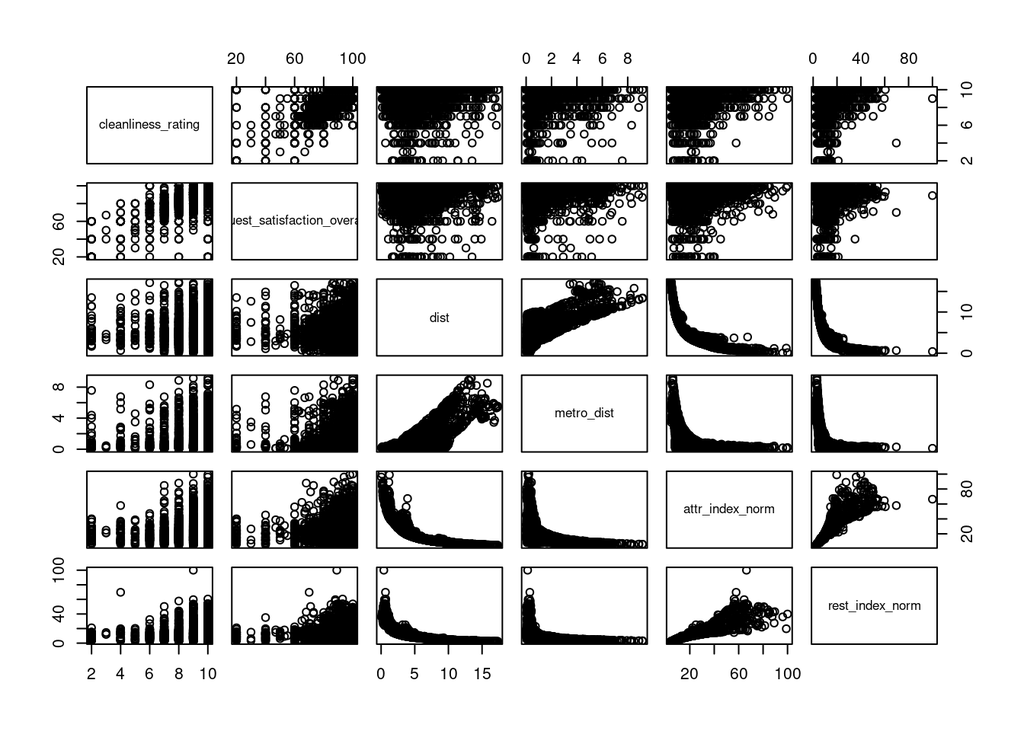

```r
london_numeric = subset(london, select = c(cleanliness_rating, guest_satisfaction_overall, dist, metro_dist, attr_index_norm, rest_index_norm))
pairs(london_numeric)
```

Some of these data show collinearity and some look non-linear. In particular, distance and metro_distance seem to be collinear.

Let us check for collinearity using the variance inflation factor.

```r
library(faraway)
vif(full_additive_mod)
```

```
##      room_typePrivate room       room_typeShared room
##                   1.800035                   1.021575
##           person_capacity3           person_capacity4
##                   1.115019                   1.736675
##           person_capacity5           person_capacity6
##                   1.329037                   2.023084
##      host_is_superhostTrue                  multiTrue
##                   1.098007                   1.334466
##                    bizTrue         cleanliness_rating
##                   1.621247                   2.315125
## guest_satisfaction_overall                  bedrooms1
##                   2.450057                   3.309820
##                  bedrooms2                  bedrooms3
##                   3.659741                   1.703254
##                  bedrooms4                  bedrooms5
##                   1.084696                   1.008342
##                  bedrooms8                       dist
##                   1.007537                   5.121200
##                 metro_dist            attr_index_norm
##                   2.750479                   7.787592
##            rest_index_norm                        lng
##                   5.818696                   1.801221
##                        lat
##                   1.495864
```

```r
vif(full_additive_mod)[unname(vif(full_additive_mod)) > 5]
```

```
##            dist attr_index_norm rest_index_norm
##        5.121200        7.787592        5.818696
```

Per the textbook, predictors with a VIF of more than 5 are suspicious for collinearity. The variables with VIF values more than 5 include dist, attr_index_norm, and rest_index_norm. This makes sense as dist is the distance to the city center, and it is likely that if this is small, the number of attractions and restaurants (as measured by attr_index_norm and rest_index_norm) would be high. There are more attractions and restaurants near the city center. Also, metro_dist, the distance to a metro station, would likely be small if dist is small. These values are not tremendously larger than 5, so we will keep them in model.

#### Transformation Analysis

What does the distribution of the room prices look like?

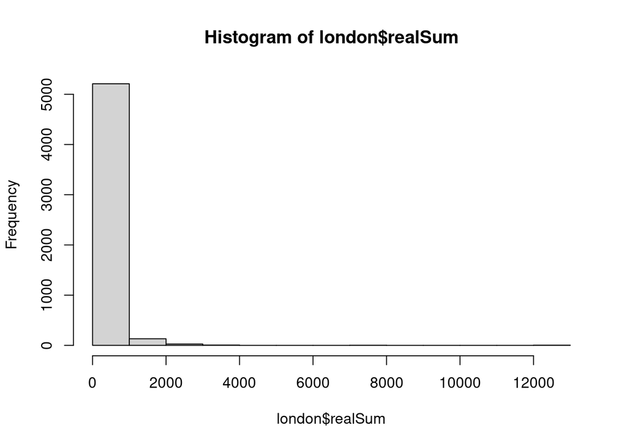

```r
hist(london$realSum)
```

Maybe this would look better if we took the logarithm. This is a typical transformation for prices that can vary over several orders of magnitude.

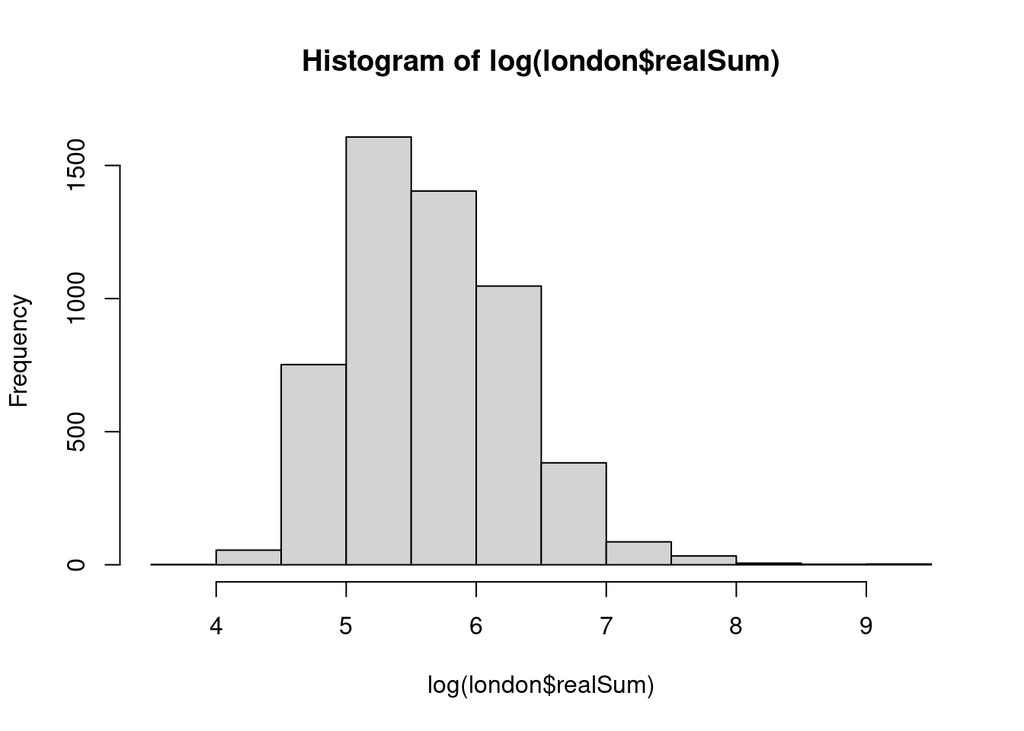

```r
hist(log(london$realSum))
```

This does look much better. Let us try to fit a model with the log transformation of the response.

```r
full_log_model = lm(log(realSum) ~ ., data = london)
summary(full_log_model)
```

```
##
## Call:
## lm(formula = log(realSum) ~ ., data = london)
##
## Residuals:
##     Min      1Q  Median      3Q     Max
## -1.0183 -0.2246 -0.0468  0.1744  4.3885
##
## Coefficients:
##                              Estimate Std. Error t value Pr(>|t|)
## (Intercept)                -3.5611851  9.6613901  -0.369  0.71244
## room_typePrivate room      -0.5814540  0.0131894 -44.085  < 2e-16 ***
## room_typeShared room       -0.7594352  0.0700080 -10.848  < 2e-16 ***
## person_capacity3            0.1038847  0.0183750   5.654 1.65e-08 ***
## person_capacity4            0.2031329  0.0164806  12.326  < 2e-16 ***
## person_capacity5            0.2565597  0.0293364   8.745  < 2e-16 ***
## person_capacity6            0.3139412  0.0273729  11.469  < 2e-16 ***
## host_is_superhostTrue       0.0302614  0.0137724   2.197  0.02805 *
## multiTrue                   0.0281435  0.0125967   2.234  0.02551 *
## bizTrue                     0.0396468  0.0130017   3.049  0.00230 **
## cleanliness_rating          0.0339220  0.0064697   5.243 1.64e-07 ***
## guest_satisfaction_overall  0.0002596  0.0006787   0.382  0.70215
## bedrooms1                   0.1087010  0.0206736   5.258 1.51e-07 ***
## bedrooms2                   0.4175121  0.0263313  15.856  < 2e-16 ***
## bedrooms3                   0.7081481  0.0432564  16.371  < 2e-16 ***
## bedrooms4                   0.3917943  0.0936144   4.185 2.89e-05 ***
## bedrooms5                   0.1216756  0.2549597   0.477  0.63321
## bedrooms8                   0.9210053  0.3603900   2.556  0.01063 *
## dist                       -0.0086148  0.0040940  -2.104  0.03540 *
## metro_dist                 -0.0403219  0.0064171  -6.284 3.57e-10 ***
## attr_index_norm             0.0100078  0.0011525   8.683  < 2e-16 ***
## rest_index_norm             0.0046483  0.0016995   2.735  0.00626 **
## lng                        -0.5868284  0.0973067  -6.031 1.74e-09 ***
## lat                         0.1688284  0.1873043   0.901  0.36744
## ---
## Signif. codes:  0 '***' 0.001 '**' 0.01 '*' 0.05 '.' 0.1 ' ' 1
##
## Residual standard error: 0.359 on 5355 degrees of freedom
## Multiple R-squared:  0.6878, Adjusted R-squared:  0.6864
## F-statistic: 512.8 on 23 and 5355 DF,  p-value: < 2.2e-16
```

The log transformation gives a much better $R^2$. The $R^2$ value increased from around 0.27 to 0.6878 with the log transform.

How is this better in terms of RMSE?

```r
summary(full_log_model)$r.squared
```

```
## [1] 0.6877577
```

```r
sqrt(mean(full_log_model$residuals^2))
```

```
## [1] 0.3582042
```

```r
sqrt(mean(full_additive_mod$residuals^2))
```

```
## [1] 372.2035
```

The log model also has much lower RMSE.

Try transformations of other variables.

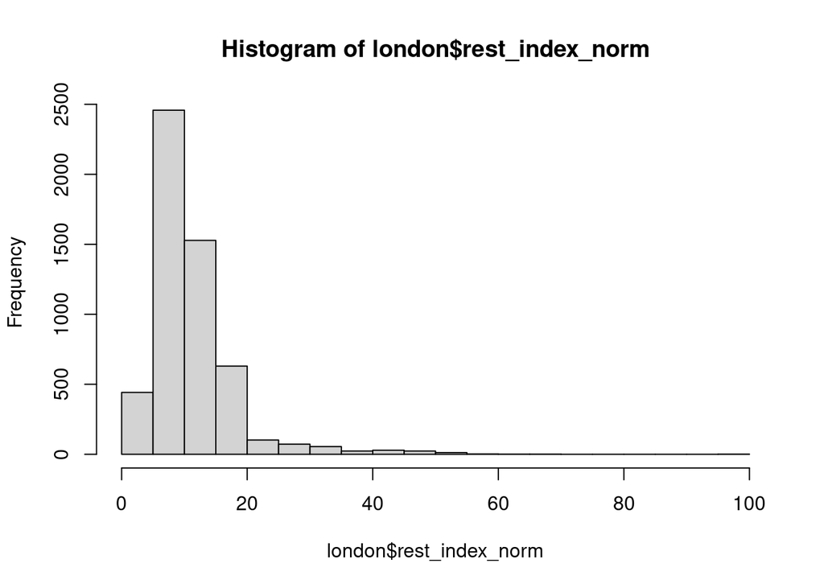

```r
hist(london$rest_index_norm)
```

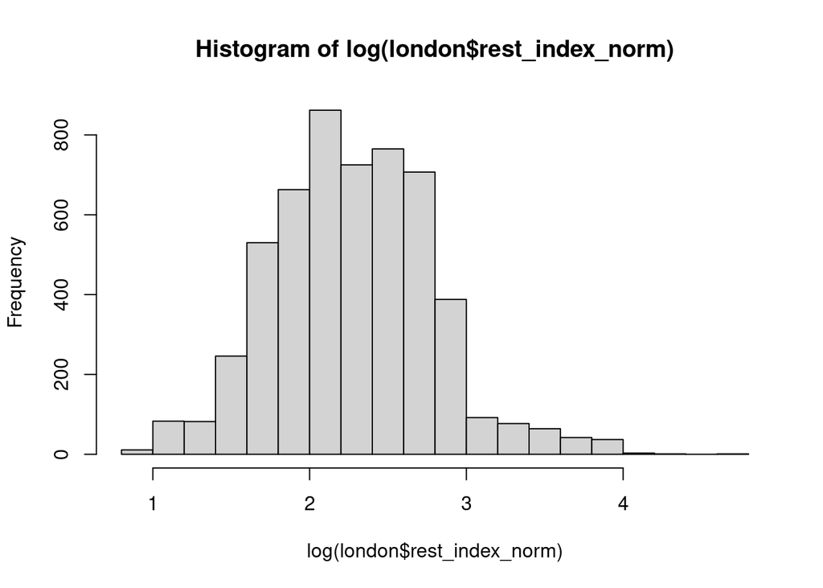

```r
hist(log(london$rest_index_norm))
```

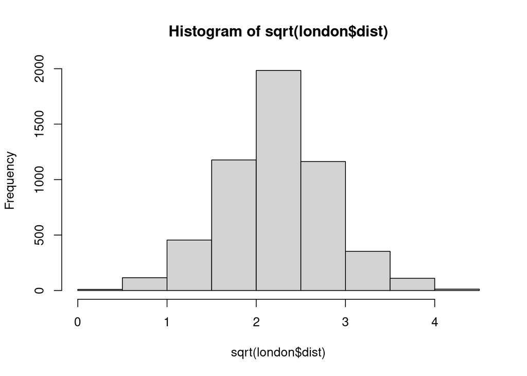

```r
hist(sqrt(london$dist))
```

Maybe transformations of other variables may be of help.

```r
print("Baseline R^2 value for the full additive log model with all predictors and log transformation of the response realSum")
```

```
## [1] "Baseline R^2 value for the full additive log model with all predictors and log transformation of the response realSum"
```

```r
summary(full_log_model)$r.squared
```

```
## [1] 0.6877577
```

```r
print("R^2 Values")
```

```
## [1] "R^2 Values"
```

```r
print("Transformations of dist")
```

```
## [1] "Transformations of dist"
```

```r
summary(lm(log(realSum) ~ . - dist + I(dist^2), data = london))$r.squared
```

```
## [1] 0.6875498
```

```r
summary(lm(log(realSum) ~ . - dist + I(dist^3), data = london))$r.squared
```

```
## [1] 0.6875018
```

```r
summary(lm(log(realSum) ~ . - dist + I(1/dist), data = london))$r.squared
```

```
## [1] 0.6883674
```

```r
summary(lm(log(realSum) ~ . - dist + log1p(dist), data = london))$r.squared
```

```
## [1] 0.6876262
```

```r
print("Transformations of metro_dist")
```

```
## [1] "Transformations of metro_dist"
```

```r
summary(lm(log(realSum) ~ . - metro_dist + I(metro_dist^2), data = london))$r.squared
```

```
## [1] 0.6863716
```

```r
summary(lm(log(realSum) ~ . - metro_dist + I(metro_dist^3), data = london))$r.squared
```

```
## [1] 0.6857905
```

```r
summary(lm(log(realSum) ~ . - metro_dist + I(1/metro_dist), data = london))$r.squared
```

```
## [1] 0.6856005
```

```r
summary(lm(log(realSum) ~ . - metro_dist + log1p(metro_dist), data = london))$r.squared
```

```
## [1] 0.6882083
```

```r
print("Transformations of cleanliness_rating")
```

```
## [1] "Transformations of cleanliness_rating"
```

```r
summary(lm(log(realSum) ~ . - cleanliness_rating + I(cleanliness_rating^2), data = london))$r.squared
```

```
## [1] 0.6897707
```

```r
summary(lm(log(realSum) ~ . - cleanliness_rating + I(cleanliness_rating^3), data = london))$r.squared
```

```
## [1] 0.6913336
```

```r
summary(lm(log(realSum) ~ . - cleanliness_rating + I(1/cleanliness_rating), data = london))$r.squared
```

```
## [1] 0.6866248
```

```r
summary(lm(log(realSum) ~ . - cleanliness_rating + log1p(cleanliness_rating), data = london))$r.squared
```

```
## [1] 0.6863446
```

```r
print("Transformations of guest_satisfaction_overall")
```

```
## [1] "Transformations of guest_satisfaction_overall"
```

```r
summary(lm(log(realSum) ~ . - guest_satisfaction_overall + I(guest_satisfaction_overall^2), data = london))$r.squared
```

```
## [1] 0.6883051
```

```r
summary(lm(log(realSum) ~ . - guest_satisfaction_overall + I(guest_satisfaction_overall^3), data = london))$r.squared
```

```
## [1] 0.689218
```

```r
summary(lm(log(realSum) ~ . - guest_satisfaction_overall + I(1/guest_satisfaction_overall), data = london))$r.squared
```

```
## [1] 0.6889857
```

```r
summary(lm(log(realSum) ~ . - guest_satisfaction_overall + log1p(guest_satisfaction_overall), data = london))$r.squared
```

```
## [1] 0.6881506
```

```r
print("Transformations of attr_index_norm")
```

```
## [1] "Transformations of attr_index_norm"
```

```r
summary(lm(log(realSum) ~ . - attr_index_norm + I(attr_index_norm^2), data = london))$r.squared
```

```
## [1] 0.6849013
```

```r
summary(lm(log(realSum) ~ . - attr_index_norm + I(attr_index_norm^3), data = london))$r.squared
```

```
## [1] 0.6840331
```

```r
summary(lm(log(realSum) ~ . - attr_index_norm + I(1/attr_index_norm), data = london))$r.squared
```

```
## [1] 0.6873292
```

```r
summary(lm(log(realSum) ~ . - attr_index_norm + log1p(attr_index_norm), data = london))$r.squared
```

```
## [1] 0.6916943
```

```r
print("Transformations of rest_index_norm")
```

```
## [1] "Transformations of rest_index_norm"
```

```r
summary(lm(log(realSum) ~ . - rest_index_norm + I(rest_index_norm^2), data = london))$r.squared
```

```
## [1] 0.687411
```

```r
summary(lm(log(realSum) ~ . - rest_index_norm + I(rest_index_norm^3), data = london))$r.squared
```

```
## [1] 0.6875759
```

```r
summary(lm(log(realSum) ~ . - rest_index_norm + I(1/rest_index_norm), data = london))$r.squared
```

```
## [1] 0.6933869
```

```r
summary(lm(log(realSum) ~ . - rest_index_norm + log1p(rest_index_norm), data = london))$r.squared
```

```
## [1] 0.6923776
```

```r
print("Transformations of lat")
```

```
## [1] "Transformations of lat"
```

```r
summary(lm(log(realSum) ~ . - lat + I(lat^2), data = london))$r.squared
```

```
## [1] 0.6877574
```

```r
summary(lm(log(realSum) ~ . - lat + I(lat^3), data = london))$r.squared
```

```
## [1] 0.6877572
```

```r
summary(lm(log(realSum) ~ . - lat + I(1/lat), data = london))$r.squared
```

```
## [1] 0.6877581
```

```r
summary(lm(log(realSum) ~ . - lat + log1p(lat), data = london))$r.squared
```

```
## [1] 0.6877579
```

```r
print("Transformations of lng")
```

```
## [1] "Transformations of lng"
```

```r
summary(lm(log(realSum) ~ . - lng + I(lng^2), data = london))$r.squared
```

```
## [1] 0.6887883
```

```r
summary(lm(log(realSum) ~ . - lng + I(lng^3), data = london))$r.squared
```

```
## [1] 0.6884524
```

```r
summary(lm(log(realSum) ~ . - lng + I(1/lng), data = london))$r.squared
```

```
## [1] 0.6857737
```

```r
summary(lm(log(realSum) ~ . - lng + log1p(lng), data = london))$r.squared
```

```
## [1] 0.6878919
```

The biggest improvement in terms of $R^2$ seems to be with 1/rest_index_norm.

How do these do in terms of RMSE?

```r
log_other_transform = lm(log(realSum) ~ . - rest_index_norm + I(1/rest_index_norm), data = london)
summary(log_other_transform)
```

```
##
## Call:
## lm(formula = log(realSum) ~ . - rest_index_norm + I(1/rest_index_norm),
##     data = london)
##
## Residuals:
##     Min      1Q  Median      3Q     Max
## -1.0062 -0.2219 -0.0449  0.1744  4.3976
##
## Coefficients:
##                              Estimate Std. Error t value Pr(>|t|)
## (Intercept)                20.6309898  9.8570773   2.093   0.0364 *
## room_typePrivate room      -0.5721234  0.0131030 -43.664  < 2e-16 ***
## room_typeShared room       -0.7495475  0.0693739 -10.804  < 2e-16 ***
## person_capacity3            0.1075660  0.0182119   5.906 3.71e-09 ***
## person_capacity4            0.2057912  0.0163333  12.600  < 2e-16 ***
## person_capacity5            0.2595280  0.0290622   8.930  < 2e-16 ***
## person_capacity6            0.3215342  0.0271158  11.858  < 2e-16 ***
## host_is_superhostTrue       0.0324788  0.0136470   2.380   0.0174 *
## multiTrue                   0.0228310  0.0124937   1.827   0.0677 .
## bizTrue                     0.0196136  0.0130414   1.504   0.1327
## cleanliness_rating          0.0328541  0.0064112   5.124 3.09e-07 ***
## guest_satisfaction_overall  0.0004863  0.0006729   0.723   0.4698
## bedrooms1                   0.1290821  0.0205891   6.269 3.91e-10 ***
## bedrooms2                   0.4381168  0.0261732  16.739  < 2e-16 ***
## bedrooms3                   0.7276612  0.0428997  16.962  < 2e-16 ***
## bedrooms4                   0.4275736  0.0928321   4.606 4.20e-06 ***
## bedrooms5                   0.1110603  0.2526526   0.440   0.6603
## bedrooms8                   0.9059932  0.3571295   2.537   0.0112 *
## dist                        0.0810139  0.0096193   8.422  < 2e-16 ***
## metro_dist                 -0.0135633  0.0068143  -1.990   0.0466 *
## attr_index_norm             0.0127936  0.0007438  17.200  < 2e-16 ***
## lng                        -0.5080711  0.0962264  -5.280 1.34e-07 ***
## lat                        -0.3003639  0.1911003  -1.572   0.1161
## I(1/rest_index_norm)       -4.7885463  0.4652517 -10.292  < 2e-16 ***
## ---
## Signif. codes:  0 '***' 0.001 '**' 0.01 '*' 0.05 '.' 0.1 ' ' 1
##
## Residual standard error: 0.3558 on 5355 degrees of freedom
## Multiple R-squared:  0.6934, Adjusted R-squared:  0.6921
## F-statistic: 526.5 on 23 and 5355 DF,  p-value: < 2.2e-16
```

```r
sqrt(mean(full_log_model$residuals^2))
```

```
## [1] 0.3582042
```

```r
sqrt(mean(log_other_transform$residuals^2))
```

```
## [1] 0.3549606
```

1/rest_index_norm also has lower RMSE.

#### Interaction Analysis

Next do a model with interactions, and then reduce the number of variables with backward AIC. We will start with the full log model.

```r
full_interact = lm(log(realSum) ~ .^2, data = london)
summary(full_interact)$r.squared
```

```
## [1] 0.7335292
```

The full interaction model has a higher $R^2$ value than any of the transformation models above. We will have to check if there is overfitting.

```r
sqrt(mean(full_interact$residuals^2))
```

```
## [1] 0.3309098
```

The full_interact model has a lower RMSE than the transformation models.

The full interaction model is quite large. Let us use AIC and BIC to reduce the number of predictors.

```r
aic_full_interact = step (full_interact, direction = "backward", trace = FALSE)
```

```r
nrow(summary(full_interact)$coeff)
```

```
## [1] 214
```

```r
nrow(summary(aic_full_interact)$coeff)
```

```
## [1] 113
```

```r
summary(aic_full_interact)$r.squared
```

```
## [1] 0.7294467
```

AIC decreases the number of coefficients from 214 in the full interaction model to 113 with a decrease in $R^2$ from 0.7335292 to 0.7294467.

Try BIC to get a smaller model

```r
bic_full_interact = step (full_interact, direction = "backward", trace = FALSE, k = log(nrow(london)))
```

```r
summary(bic_full_interact)
```

```
##
## Call:
## lm(formula = log(realSum) ~ room_type + person_capacity + multi +
##     biz + cleanliness_rating + guest_satisfaction_overall + bedrooms +
##     dist + metro_dist + attr_index_norm + rest_index_norm + lng +
##     lat + room_type:bedrooms + multi:guest_satisfaction_overall +
##     biz:cleanliness_rating + biz:lat + cleanliness_rating:guest_satisfaction_overall +
##     cleanliness_rating:attr_index_norm + bedrooms:attr_index_norm +
##     dist:metro_dist + dist:rest_index_norm + dist:lng + dist:lat +
##     metro_dist:attr_index_norm + metro_dist:rest_index_norm +
##     attr_index_norm:rest_index_norm + rest_index_norm:lat, data = london)
##
## Residuals:
##     Min      1Q  Median      3Q     Max
## -1.0015 -0.2149 -0.0389  0.1660  4.4094
##
## Coefficients: (9 not defined because of singularities)
##                                                 Estimate Std. Error t value
## (Intercept)                                   -5.357e+02  1.129e+02  -4.747
## room_typePrivate room                         -2.458e-01  4.794e-02  -5.127
## room_typeShared room                          -7.945e-01  6.693e-02 -11.871
## person_capacity3                               1.098e-01  1.764e-02   6.228
## person_capacity4                               1.970e-01  1.585e-02  12.427
## person_capacity5                               2.396e-01  2.822e-02   8.493
## person_capacity6                               2.910e-01  2.682e-02  10.851
## multiTrue                                     -4.235e-01  1.037e-01  -4.083
## bizTrue                                        1.024e+02  2.003e+01   5.115
## cleanliness_rating                            -1.558e-01  1.650e-02  -9.443
## guest_satisfaction_overall                    -1.617e-02  1.528e-03 -10.579
## bedrooms1                                      1.854e-01  4.812e-02   3.852
## bedrooms2                                      3.641e-01  5.363e-02   6.788
## bedrooms3                                      4.303e-01  7.617e-02   5.650
## bedrooms4                                      7.707e-01  1.735e-01   4.443
## bedrooms5                                     -3.383e-01  9.245e-01  -0.366
## bedrooms8                                      6.835e-01  3.474e-01   1.967
## dist                                           5.068e+01  1.006e+01   5.039
## metro_dist                                     1.145e-01  5.066e-02   2.259
## attr_index_norm                                5.453e-03  4.659e-03   1.171
## rest_index_norm                                3.033e+01  6.978e+00   4.346
## lng                                           -2.441e+00  2.943e-01  -8.293
```

[output cut: 78 more lines]

```
## bedrooms8:attr_index_norm                           NA
## dist:metro_dist                               3.42e-05 ***
## dist:rest_index_norm                          3.10e-08 ***
## dist:lng                                      2.93e-12 ***
## dist:lat                                      4.88e-07 ***
## metro_dist:attr_index_norm                    6.18e-05 ***
## metro_dist:rest_index_norm                    0.000847 ***
## attr_index_norm:rest_index_norm               0.000753 ***
## rest_index_norm:lat                           1.42e-05 ***
## ---
## Signif. codes:  0 '***' 0.001 '**' 0.01 '*' 0.05 '.' 0.1 ' ' 1
##
## Residual standard error: 0.3424 on 5334 degrees of freedom
## Multiple R-squared:  0.7171, Adjusted R-squared:  0.7148
## F-statistic: 307.3 on 44 and 5334 DF,  p-value: < 2.2e-16
```

```r
nrow(summary(bic_full_interact)$coeff)
```

```
## [1] 45
```

```r
nrow(summary(bic_full_interact)$coeff)
```

```
## [1] 45
```

```r
summary(bic_full_interact)$r.squared
```

```
## [1] 0.7171065
```

```r
sqrt(mean(bic_full_interact$residuals^2))
```

```
## [1] 0.3409544
```

BIC decreases the number of coefficients from 214 in the full interaction model to 45 with a decrease in $R^2$ from 0.7335292 to 0.7171065.

#### Putting It Together

Try a model with transformations and interactions. Start with the model from the BIC elimination above and add the 1/rest_index_norm transformation.

```r
combined_model =  lm(log(realSum) ~ room_type + person_capacity + multi +
    biz + cleanliness_rating + guest_satisfaction_overall + bedrooms +
    dist + metro_dist + attr_index_norm + rest_index_norm + lng +
    lat + room_type:bedrooms + multi:guest_satisfaction_overall +
    biz:cleanliness_rating + biz:lat + cleanliness_rating:guest_satisfaction_overall +
    cleanliness_rating:attr_index_norm + bedrooms:attr_index_norm +
    dist:metro_dist + dist:rest_index_norm + dist:lng + dist:lat +
    metro_dist:attr_index_norm + metro_dist:rest_index_norm +
    attr_index_norm:rest_index_norm + rest_index_norm:lat
    + I(1/rest_index_norm), data = london)

nrow(summary(combined_model)$coeff)
```

```
## [1] 46
```

```r
summary(combined_model)$r.squared
```

```
## [1] 0.7186907
```

```r
sqrt(mean(combined_model$residuals^2))
```

```
## [1] 0.3399984
```

Adding 1/rest_index_norm marginally increases $R^2$.

Let us remove predictors to increase explanatory power. I removed predictors with collinearity and low p-values

```r
smaller_combined_model =  lm(log(realSum) ~ room_type + person_capacity + cleanliness_rating + guest_satisfaction_overall
                     + bedrooms + dist + attr_index_norm  + lng +
                     + multi:guest_satisfaction_overall + biz:cleanliness_rating
                     + cleanliness_rating:guest_satisfaction_overall
                     + dist:rest_index_norm + metro_dist:attr_index_norm, data = london)

vif(smaller_combined_model)
```

```
##                         room_typePrivate room
##                                      1.797109
##                          room_typeShared room
##                                      1.020941
##                              person_capacity3
##                                      1.114337
##                              person_capacity4
##                                      1.732889
##                              person_capacity5
##                                      1.328297
##                              person_capacity6
##                                      2.018781
##                            cleanliness_rating
##                                     11.830130
##                    guest_satisfaction_overall
##                                     12.912596
##                                     bedrooms1
##                                      3.358780
##                                     bedrooms2
##                                      3.691527
##                                     bedrooms3
##                                      1.711460
##                                     bedrooms4
##                                      1.085808
##                                     bedrooms5
##                                      1.007189
##                                     bedrooms8
##                                      1.006449
##                                          dist
##                                      3.636849
##                               attr_index_norm
##                                      3.735503
##                                           lng
##                                      1.522141
##          guest_satisfaction_overall:multiTrue
##                                      1.313012
##                    cleanliness_rating:bizTrue
##                                      1.616445
## cleanliness_rating:guest_satisfaction_overall
##                                     36.445683
##                          dist:rest_index_norm
##                                      1.559669
##                    attr_index_norm:metro_dist
##                                      1.538521
```

```r
summary(smaller_combined_model)
```

```
##
## Call:
## lm(formula = log(realSum) ~ room_type + person_capacity + cleanliness_rating +
##     guest_satisfaction_overall + bedrooms + dist + attr_index_norm +
##     lng + +multi:guest_satisfaction_overall + biz:cleanliness_rating +
##     cleanliness_rating:guest_satisfaction_overall + dist:rest_index_norm +
##     metro_dist:attr_index_norm, data = london)
##
## Residuals:
##     Min      1Q  Median      3Q     Max
## -0.9903 -0.2207 -0.0421  0.1719  4.4621
##
## Coefficients:
##                                                 Estimate Std. Error t value
## (Intercept)                                    5.8945083  0.1238904  47.578
## room_typePrivate room                         -0.5706453  0.0129340 -44.120
## room_typeShared room                          -0.7657904  0.0686874 -11.149
## person_capacity3                               0.1098166  0.0180285   6.091
## person_capacity4                               0.2062127  0.0161571  12.763
## person_capacity5                               0.2468237  0.0287839   8.575
## person_capacity6                               0.3173272  0.0268363  11.825
## cleanliness_rating                            -0.1110253  0.0143534  -7.735
## guest_satisfaction_overall                    -0.0148803  0.0015292  -9.731
## bedrooms1                                      0.1308416  0.0204394   6.401
## bedrooms2                                      0.4389107  0.0259546  16.911
## bedrooms3                                      0.7343243  0.0425557  17.256
## bedrooms4                                      0.4268793  0.0919241   4.644
## bedrooms5                                      0.1329714  0.2500847   0.532
## bedrooms8                                      0.9563343  0.3535104   2.705
## dist                                          -0.0192514  0.0033860  -5.686
## attr_index_norm                                0.0145026  0.0007834  18.512
## lng                                           -0.5792331  0.0877912  -6.598
## guest_satisfaction_overall:multiTrue           0.0003809  0.0001315   2.896
## cleanliness_rating:bizTrue                     0.0057453  0.0014126   4.067
## cleanliness_rating:guest_satisfaction_overall  0.0019138  0.0001708  11.202
## dist:rest_index_norm                           0.0069852  0.0007526   9.282
## attr_index_norm:metro_dist                    -0.0028008  0.0005813  -4.818
##                                               Pr(>|t|)
## (Intercept)                                    < 2e-16 ***
## room_typePrivate room                          < 2e-16 ***
```

[output cut: 12 more lines]

```
## bedrooms8                                      0.00685 **
## dist                                          1.37e-08 ***
## attr_index_norm                                < 2e-16 ***
## lng                                           4.57e-11 ***
## guest_satisfaction_overall:multiTrue           0.00379 **
## cleanliness_rating:bizTrue                    4.82e-05 ***
## cleanliness_rating:guest_satisfaction_overall  < 2e-16 ***
## dist:rest_index_norm                           < 2e-16 ***
## attr_index_norm:metro_dist                    1.49e-06 ***
## ---
## Signif. codes:  0 '***' 0.001 '**' 0.01 '*' 0.05 '.' 0.1 ' ' 1
##
## Residual standard error: 0.3523 on 5356 degrees of freedom
## Multiple R-squared:  0.6992, Adjusted R-squared:  0.6979
## F-statistic: 565.9 on 22 and 5356 DF,  p-value: < 2.2e-16
```

```r
summary(smaller_combined_model)$r.squared
```

```
## [1] 0.6991838
```

```r
sqrt(mean(smaller_combined_model$residuals^2))
```

```
## [1] 0.3515891
```

```r
anova(smaller_combined_model, combined_model)
```

```
## Analysis of Variance Table
##
## Model 1: log(realSum) ~ room_type + person_capacity + cleanliness_rating +
##     guest_satisfaction_overall + bedrooms + dist + attr_index_norm +
##     lng + +multi:guest_satisfaction_overall + biz:cleanliness_rating +
##     cleanliness_rating:guest_satisfaction_overall + dist:rest_index_norm +
##     metro_dist:attr_index_norm
## Model 2: log(realSum) ~ room_type + person_capacity + multi + biz + cleanliness_rating +
##     guest_satisfaction_overall + bedrooms + dist + metro_dist +
##     attr_index_norm + rest_index_norm + lng + lat + room_type:bedrooms +
##     multi:guest_satisfaction_overall + biz:cleanliness_rating +
##     biz:lat + cleanliness_rating:guest_satisfaction_overall +
##     cleanliness_rating:attr_index_norm + bedrooms:attr_index_norm +
##     dist:metro_dist + dist:rest_index_norm + dist:lng + dist:lat +
##     metro_dist:attr_index_norm + metro_dist:rest_index_norm +
##     attr_index_norm:rest_index_norm + rest_index_norm:lat + I(1/rest_index_norm)
##   Res.Df    RSS Df Sum of Sq      F    Pr(>F)
## 1   5356 664.92
## 2   5333 621.81 23    43.118 16.078 < 2.2e-16 ***
## ---
## Signif. codes:  0 '***' 0.001 '**' 0.01 '*' 0.05 '.' 0.1 ' ' 1
```

```r
anova(combined_model, full_interact)
```

```
## Analysis of Variance Table
##
## Model 1: log(realSum) ~ room_type + person_capacity + multi + biz + cleanliness_rating +
##     guest_satisfaction_overall + bedrooms + dist + metro_dist +
##     attr_index_norm + rest_index_norm + lng + lat + room_type:bedrooms +
##     multi:guest_satisfaction_overall + biz:cleanliness_rating +
##     biz:lat + cleanliness_rating:guest_satisfaction_overall +
##     cleanliness_rating:attr_index_norm + bedrooms:attr_index_norm +
##     dist:metro_dist + dist:rest_index_norm + dist:lng + dist:lat +
##     metro_dist:attr_index_norm + metro_dist:rest_index_norm +
##     attr_index_norm:rest_index_norm + rest_index_norm:lat + I(1/rest_index_norm)
## Model 2: log(realSum) ~ (room_type + person_capacity + host_is_superhost +
##     multi + biz + cleanliness_rating + guest_satisfaction_overall +
##     bedrooms + dist + metro_dist + attr_index_norm + rest_index_norm +
##     lng + lat)^2
##   Res.Df    RSS  Df Sum of Sq     F    Pr(>F)
## 1   5333 621.81
## 2   5165 589.01 168    32.799 1.712 5.162e-08 ***
## ---
## Signif. codes:  0 '***' 0.001 '**' 0.01 '*' 0.05 '.' 0.1 ' ' 1
```

```r
require(caret)
require(dplyr)
require(tidyverse)
###full_additive_mod

### Data splitting: leave one out
train.loocv <- trainControl(method = "LOOCV")

### Training
model.loocv <- train(realSum ~ ., data = london,
                     method = "lm",
                     trControl = train.loocv)

### Present results
print(model.loocv)
```

```
## Linear Regression
##
## 5379 samples
##   14 predictor
##
## No pre-processing
## Resampling: Leave-One-Out Cross-Validation
## Summary of sample sizes: 5378, 5378, 5378, 5378, 5378, 5378, ...
## Resampling results:
##
##   RMSE      Rsquared   MAE
##   374.9735  0.2661919  122.4237
##
## Tuning parameter 'intercept' was held constant at a value of TRUE
```

```r
###full_log_model

### Data splitting: leave one out
train.loocv <- trainControl(method = "LOOCV")

### Training
model.loocv <- train(log(realSum) ~ ., data = london,
                     method = "lm",
                     trControl = train.loocv)

### Present results
print(model.loocv)
```

```
## Linear Regression
##
## 5379 samples
##   14 predictor
##
## No pre-processing
## Resampling: Leave-One-Out Cross-Validation
## Summary of sample sizes: 5378, 5378, 5378, 5378, 5378, 5378, ...
## Resampling results:
##
##   RMSE       Rsquared   MAE
##   0.3603505  0.6840118  0.2615459
##
## Tuning parameter 'intercept' was held constant at a value of TRUE
```

```r
###log_other_transforms

### Data splitting: leave one out
train.loocv <- trainControl(method = "LOOCV")

### Training
model.loocv <- train(log(realSum) ~ . - rest_index_norm + I(1/rest_index_norm),
                     data = london,
                     method = "lm",
                     trControl = train.loocv)

### Present results
print(model.loocv)
```

```
## Linear Regression
##
## 5379 samples
##   14 predictor
##
## No pre-processing
## Resampling: Leave-One-Out Cross-Validation
## Summary of sample sizes: 5378, 5378, 5378, 5378, 5378, 5378, ...
## Resampling results:
##
##   RMSE       Rsquared   MAE
##   0.3570356  0.6897981  0.2594358
##
## Tuning parameter 'intercept' was held constant at a value of TRUE
```

```r
log_other_transform
```

```
##
## Call:
## lm(formula = log(realSum) ~ . - rest_index_norm + I(1/rest_index_norm),
##     data = london)
##
## Coefficients:
##                (Intercept)       room_typePrivate room
##                 20.6309898                  -0.5721234
##       room_typeShared room            person_capacity3
##                 -0.7495475                   0.1075660
##           person_capacity4            person_capacity5
##                  0.2057912                   0.2595280
##           person_capacity6       host_is_superhostTrue
##                  0.3215342                   0.0324788
##                  multiTrue                     bizTrue
##                  0.0228310                   0.0196136
##         cleanliness_rating  guest_satisfaction_overall
##                  0.0328541                   0.0004863
##                  bedrooms1                   bedrooms2
##                  0.1290821                   0.4381168
##                  bedrooms3                   bedrooms4
##                  0.7276612                   0.4275736
##                  bedrooms5                   bedrooms8
##                  0.1110603                   0.9059932
##                       dist                  metro_dist
##                  0.0810139                  -0.0135633
##            attr_index_norm                         lng
##                  0.0127936                  -0.5080711
##                        lat        I(1/rest_index_norm)
##                 -0.3003639                  -4.7885463
```

```r
### Present results
print(model.loocv)
```

[output not shown]

```r
### Present results
print(model.loocv)
```

[output not shown]

```r
### Present results
print(model.loocv)
```

[output not shown]

```r
##smaller_combined_model

### Data splitting: leave one out
train.loocv <- trainControl(method = "LOOCV")

### Training
model.loocv <- train(log(realSum) ~ room_type + person_capacity + cleanliness_rating + guest_satisfaction_overall
                     + bedrooms + dist + attr_index_norm  + lng
                     + multi:guest_satisfaction_overall + biz:cleanliness_rating
                     + cleanliness_rating:guest_satisfaction_overall
                     + dist:rest_index_norm + metro_dist:attr_index_norm, data = london,
                     method = "lm",
                     trControl = train.loocv)
### Present results
print(model.loocv)
```

```
## Linear Regression
##
## 5379 samples
##   12 predictor
##
## No pre-processing
## Resampling: Leave-One-Out Cross-Validation
## Summary of sample sizes: 5378, 5378, 5378, 5378, 5378, 5378, ...
## Resampling results:
##
##   RMSE       Rsquared   MAE
##   0.3536701  0.6956188  0.2565439
##
## Tuning parameter 'intercept' was held constant at a value of TRUE
```

```r
library(knitr)
model_table = read.csv("model_table.csv")
kable(model_table)
```

| Model.Name | Description | RMSE | R.2 | LOOCV…RMSE | Comments |
| --- | --- | --- | --- | --- | --- |
| full_additive_mod | Additive model with all possible predictors. No interactions or transforms. | 372.2035000 | 0.2768903 | 374.9735000 | Really poor fit |
| full_log_model | Same as full additive model, except log transform of response | 0.3582042 | 0.6877577 | 0.3603505 | Single biggest improvement |
| log_other_transforms | Adding 1/rest_index_norm to full_log_model | 0.3549606 | 0.6933869 | 0.3570356 | Doesn’t add much |
| full_interact | First order interaction of all predictors, log transformation of response | 0.3309098 | 0.7335292 | 1.1167490 | Overfit |
| bic_full_interact | full_interact model reduced using BIC | 0.3409544 | 0.7171065 | 0.3460632 |  |
| combined_model | Combine interactions and transformations, starting with bic_full_interact | 0.3399984 | 0.7186907 | 0.3452113 |  |
| smaller_combined_model | Reduce extraneous predictors from combined_model | 0.3515891 | 0.6991838 | 0.3536701 |  |